[figure not shown]

# Taller de análisis de datos - *Jose Alexander Ríos Trespalacios*

Los siguientes ejercicios corresponden al taller de análisis de datos. Estos ejercicios deben ser realizados en los mismos grupos (individuales o en parejas) en los que se entregó la tarea de clase que hace parte de este taller.

# a. Análisis exploratorio de datos (50%):

### **1. Proceso estándar entre industrias para la minería de datos**

• **Entendimiento de Negocios** ¿Qué atributos incrementan o decrementan el valor final de la propiedad a comprar? ¿Por qué el área total de la vivienda está altamente relacionada con su valor final? ¿El precio final de la vivienda está relacionado con el número de habitaciones o la cantidad de baños? ¿El sector donde se encuentra la vivienda puede decirnos (no en valores exactos) que tan costosa puede ser la vivienda?

• Riesgos: Algunos atributos pueden presentar problemas a la hora de predecir el precio, por ejemplo, el área en pies cuadrados no siempre se muestra como un valor absoluto, hay 248 datos que muestra este registro en un rango. Para tal caso, solo podemos tomar el promedio del valor mínimo y máximo en el rango.

• **Comprensión de datos y preparación de datos**

Hay ciertos atributos que se relacionan directamente con el precio final de vivienda (siendo el área en pies cuadrados la más relevante, aunque tienen cierta dependencia entre ellas, una vivienda puede ser grande y estar ubicada en un sector poco valorizado), el precio puede reducirse o aumentarse en consecuencia. Algunos datos contienen valores faltantes, por lo tanto, es necesaria el barrido de datos.

Hay datos importantes en la tabla que sirven para predecir el precio final y son cualitativos (ubicación), esta ubicación es fundamental porque hay sectores más valorizados que otros, por lo tanto se debe hacer un estudio a fondo para ver analizar como varía el precio con respecto a este atributo.

• **Modelación** En un modelo econométrico, las variables representan a los conceptos u operaciones económicas que queremos analizar. Normalmente utilizamos variables cuantitativas, es decir, aquellas cuyos valores vienen expresados de forma numérica; sin embargo, también existe la posibilidad de incluir en el modelo econométrico información cualitativa, siempre que esta pueda expresarse de esa forma.

Cuando usamos regresión lineal, la variable dependiente y siempre es numérica. Por ejemplo, precios de las casas, numero de baños, area_total etc. En la tabla tenemos datos importantes culitativos, estos podrian representarse con valores numericos y luego al reemplazarlos se podrá predecir el precio final de la vivienda.

### **2. Carga de datos**

```python
import pandas as pd

dataset = pd.read_csv('data/Bengaluru_House_Data.csv')
dataset_bereshit = pd.read_csv('data/Bengaluru_House_Data.csv')
```

### **3. Visualización y análisis**

```python
dataset.head()
```

|  | area_type | availability | location | size | society | total_sqft | bath | balcony | price |
| --- | --- | --- | --- | --- | --- | --- | --- | --- | --- |
| 0 | Super built-up Area | 19-Dec | Electronic City Phase II | 2 BHK | Coomee | 1056 | 2.0 | 1.0 | 39.07 |
| 1 | Plot Area | Ready To Move | Chikka Tirupathi | 4 Bedroom | Theanmp | 2600 | 5.0 | 3.0 | 120.00 |
| 2 | Built-up Area | Ready To Move | Uttarahalli | 3 BHK | NaN | 1440 | 2.0 | 3.0 | 62.00 |
| 3 | Super built-up Area | Ready To Move | Lingadheeranahalli | 3 BHK | Soiewre | 1521 | 3.0 | 1.0 | 95.00 |
| 4 | Super built-up Area | Ready To Move | Kothanur | 2 BHK | NaN | 1200 | 2.0 | 1.0 | 51.00 |

```python
# Cambiamos el nombre de la columna para poder manipular mejor la información
dataset.columns = ['tipo_area', 'disponibilidad', 'ubicación', 'num_habitaciones', 'sociedad', 'area_total', 'baños', 'balcones', 'precio']
dataset_bereshit.columns = ['tipo_area', 'disponibilidad', 'ubicación', 'num_habitaciones', 'sociedad', 'area_total', 'baños', 'balcones', 'precio']
```

```python
dataset.head()
```

|  | tipo_area | disponibilidad | ubicación | num_habitaciones | sociedad | area_total | baños | balcones | precio |
| --- | --- | --- | --- | --- | --- | --- | --- | --- | --- |
| 0 | Super built-up Area | 19-Dec | Electronic City Phase II | 2 BHK | Coomee | 1056 | 2.0 | 1.0 | 39.07 |
| 1 | Plot Area | Ready To Move | Chikka Tirupathi | 4 Bedroom | Theanmp | 2600 | 5.0 | 3.0 | 120.00 |
| 2 | Built-up Area | Ready To Move | Uttarahalli | 3 BHK | NaN | 1440 | 2.0 | 3.0 | 62.00 |
| 3 | Super built-up Area | Ready To Move | Lingadheeranahalli | 3 BHK | Soiewre | 1521 | 3.0 | 1.0 | 95.00 |
| 4 | Super built-up Area | Ready To Move | Kothanur | 2 BHK | NaN | 1200 | 2.0 | 1.0 | 51.00 |

Se puede ver que en columna **"area_total"** se encuentran valores expresados en rangos, se crea función para obtener dichos valores y sacar su promedio.

```python
## Se crea función para obtener promedio de los valores en rangos
def promedio_area_total(x):
    dato = x.split('-') #Divide 2100 - 2850 en dos datos diferentes
    if len(dato)==2:
        maximo = max(float(dato[0]), float(dato[1]))
        minimo = min(float(dato[0]), float(dato[1]))
        promedio = (maximo+minimo)/2
        return (promedio)
    try:
        return float(x)
    except:
        return None
```

Tambien en la columna "area_total" hay valores que estan expresados en otras unidades, se obtienen las unidades y se convierten

```python
unidades = {'Sq. Meter': 10.764, 'Perch':272.25, 'Sq. Yards':9,
     'Acres':43560,'Guntha':1089,'Grounds':2400.35}

df = dataset.copy()
dataset['unidades'] = dataset['area_total'].str.extract(f'({"|".join(unidades)})', expand=False)
dataset['map'] = dataset['unidades'].map(unidades).fillna(1)
dataset['area_total'] = df.area_total.apply(promedio_area_total).mul(dataset['map'])

dataset.head()
```

|  | tipo_area | disponibilidad | ubicación | num_habitaciones | sociedad | area_total | baños | balcones | precio | unidades | map |
| --- | --- | --- | --- | --- | --- | --- | --- | --- | --- | --- | --- |
| 0 | Super built-up Area | 19-Dec | Electronic City Phase II | 2 BHK | Coomee | 1056.0 | 2.0 | 1.0 | 39.07 | NaN | 1.0 |
| 1 | Plot Area | Ready To Move | Chikka Tirupathi | 4 Bedroom | Theanmp | 2600.0 | 5.0 | 3.0 | 120.00 | NaN | 1.0 |
| 2 | Built-up Area | Ready To Move | Uttarahalli | 3 BHK | NaN | 1440.0 | 2.0 | 3.0 | 62.00 | NaN | 1.0 |
| 3 | Super built-up Area | Ready To Move | Lingadheeranahalli | 3 BHK | Soiewre | 1521.0 | 3.0 | 1.0 | 95.00 | NaN | 1.0 |
| 4 | Super built-up Area | Ready To Move | Kothanur | 2 BHK | NaN | 1200.0 | 2.0 | 1.0 | 51.00 | NaN | 1.0 |

```python
print(dataset['area_total'])
```

```
0        1056.0
1        2600.0
2        1440.0
3        1521.0
4        1200.0
          ...
13315    3453.0
13316    3600.0
13317    1141.0
13318    4689.0
13319     550.0
Name: area_total, Length: 13320, dtype: float64
```

- Podemos obtener el precio total por area

```python
dataset['precio_per_area_total'] = dataset['precio']*100000 / dataset['area_total']
dataset.head()
```

|  | tipo_area | disponibilidad | ubicación | num_habitaciones | sociedad | area_total | baños | balcones | precio | unidades | map | precio_per_area_total |
| --- | --- | --- | --- | --- | --- | --- | --- | --- | --- | --- | --- | --- |
| 0 | Super built-up Area | 19-Dec | Electronic City Phase II | 2 BHK | Coomee | 1056.0 | 2.0 | 1.0 | 39.07 | NaN | 1.0 | 3699.810606 |
| 1 | Plot Area | Ready To Move | Chikka Tirupathi | 4 Bedroom | Theanmp | 2600.0 | 5.0 | 3.0 | 120.00 | NaN | 1.0 | 4615.384615 |
| 2 | Built-up Area | Ready To Move | Uttarahalli | 3 BHK | NaN | 1440.0 | 2.0 | 3.0 | 62.00 | NaN | 1.0 | 4305.555556 |
| 3 | Super built-up Area | Ready To Move | Lingadheeranahalli | 3 BHK | Soiewre | 1521.0 | 3.0 | 1.0 | 95.00 | NaN | 1.0 | 6245.890861 |
| 4 | Super built-up Area | Ready To Move | Kothanur | 2 BHK | NaN | 1200.0 | 2.0 | 1.0 | 51.00 | NaN | 1.0 | 4250.000000 |

### **Imputar/reemplazar valores faltantes con modo**

*Una técnica es la imputación de modo en la que los valores que faltan se reemplazan con el valor de modo o el valor más frecuente de toda la columna de características. Cuando los datos están sesgados, es bueno considerar el uso de valores de moda para reemplazar los valores que faltan. Para puntos de datos como el campo de salario, puede considerar usar el modo para reemplazar los valores. Tenga en cuenta que la imputación de datos faltantes con valores de moda se puede hacer con datos numéricos y categóricos.*

```python
dataset['baños'] = dataset['baños'].fillna(dataset['baños'].mode()[0])
dataset['area_total'] = dataset['area_total'].fillna(dataset['area_total'].mode()[0])
dataset['balcones'] = dataset['balcones'].fillna(dataset['balcones'].mode()[0])
dataset['num_habitaciones'] = dataset['num_habitaciones'].fillna(dataset['num_habitaciones'].mode()[0])
dataset['ubicación'] = dataset['ubicación'].fillna(dataset['ubicación'].mode()[0])
```

### Estadísticos descriptivos y análisis

```python
dataset.describe().round(1)
```

|  | area_total | baños | balcones | precio | map | precio_per_area_total |
| --- | --- | --- | --- | --- | --- | --- |
| count | 13320.0 | 13320.0 | 13320.0 | 13320.0 | 13320.0 | 13274.0 |
| mean | 1558.4 | 2.7 | 1.6 | 112.6 | 27.5 | 7907.5 |
| std | 1236.4 | 1.3 | 0.8 | 149.0 | 1067.5 | 106429.6 |
| min | 1.0 | 1.0 | 0.0 | 8.0 | 1.0 | 267.8 |
| 25% | 1100.0 | 2.0 | 1.0 | 50.0 | 1.0 | 4266.9 |
| 50% | 1275.0 | 2.0 | 2.0 | 72.0 | 1.0 | 5434.3 |
| 75% | 1678.0 | 3.0 | 2.0 | 120.0 | 1.0 | 7311.7 |
| max | 52272.0 | 40.0 | 3.0 | 3600.0 | 43560.0 | 12000000.0 |

- Se pueden ver varios valores atipicos entre las variables, por ejemplo (baños: 40 y area total:52272), no es normal que una propiedad tenga 40 baños, quizás se agregó el dato mal, además aparece una vivienda con una area muy grande, alejada del promedio de areas totales.
- Incluso se muestra un valor de un precio muy elevado, tambien podría ser un valor atipico, sin embargo, puede que sea una casa especial, en algun sector muy lujuso y exclusivo.

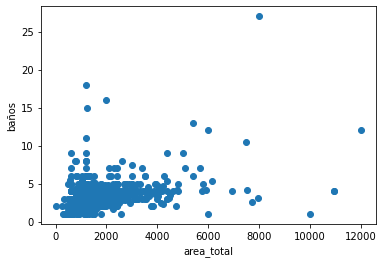

```python
import matplotlib.pyplot as plt

# Obtener promedios de las variables númericas por estado
area = dataset.groupby(["ubicación"]).mean().reset_index()

# Elegir columnas a visualizar
area = area[["ubicación","area_total","baños"]]

# Crear gráfico de dispersión con dos de las columnas
plt.scatter(x = area["area_total"],
            y = area["baños"])

# Pintar los ejes
plt.xlabel("area_total")
plt.ylabel("baños")
```

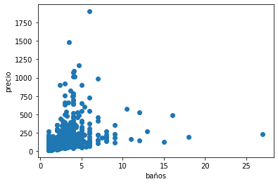

```python
area = dataset.groupby(["ubicación"]).mean().reset_index()

# Elegir columnas a visualizar
area = area[["ubicación","baños","precio"]]

# Crear gráfico de dispersión con dos de las columnas
plt.scatter(x = area["baños"],
            y = area["precio"])

# Pintar los ejes
plt.xlabel("baños")
plt.ylabel("precio")
```

### Correlación clásica (Pearson)

Para esto, desde la parte de análisis descriptivo, se suele usar principalmente la correlación.

La forma más común de analizar dichas correlaciones es utilizar la matriz de correlación clásica de las variables (correlación de Pearson).

```python
#dataset = dataset[['tipo_area', 'disponibilidad', 'ubicación', 'num_habitaciones', 'bhk','sociedad', 'area_total', 'baños', 'balcones', 'precio']]
dataset.corr()
```

[output not shown]

### **El dato que más influye en el precio vinal de la viviendo es el area total en pies cuadrados, segudio del numero de baños o habitaciones.**

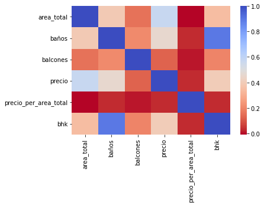

```python
### Verla como heatmap
import seaborn as sns
# calculate the correlation matrix
corr = dataset.corr()

# plot the heatmap
sns.heatmap(corr,
        xticklabels=corr.columns,
        yticklabels=corr.columns, cmap='coolwarm_r')
```

### **4. Diccionario de datos**

[figure not shown]

### **5. Dimensiones de calidad**

#### • **Completitud**

No todas las columnas tienen la información completa, solo 4 de ellas tienen todos los datos, sin embargo, no llegaría a ser un problema para la predicción ya que los atributos más importantes tienen sus datos casi completos.

```python
print("DATOS NULOS")
print("Col -                Datos")
print(dataset_bereshit.isnull().sum())
```

```
DATOS NULOS
Col -                Datos
tipo_area              0
disponibilidad         0
ubicación              1
num_habitaciones      16
sociedad            5502
area_total             0
baños                 73
balcones             609
precio                 0
dtype: int64
```

**Datos después de haber rellenado todos los valores faltantes**

```python
print("DATOS NULOS")
print("Col -                Datos")
print(dataset.isnull().sum())
```

[output not shown]

#### • **Conformidad**

```python
dataset_bereshit.dtypes
```

```
tipo_area            object
disponibilidad       object
ubicación            object
num_habitaciones     object
sociedad             object
area_total           object
baños               float64
balcones            float64
precio              float64
dtype: object
```

```python
dataset.dtypes
```

[output not shown]

La columna disponibiidad no tiene un formato estandar, aparecen datos con estos dos tipos de formato "Ready To Move" y una fecha "18-Jun", puede presentar problemas, pero solo se podría aplicar un filtro que separe cada formato.

```python
print(dataset['disponibilidad'])
```

```
0               19-Dec
1        Ready To Move
2        Ready To Move
3        Ready To Move
4        Ready To Move
             ...
13315    Ready To Move
13316    Ready To Move
13317    Ready To Move
13318           18-Jun
13319    Ready To Move
Name: disponibilidad, Length: 13320, dtype: object
```

La columna "num_habitaciones" contiene dos formatos, por lo que puede generar problemas a la hora de interpretarlos, una solución para esto es extraer el número total de habitaciones:

- En el formato 3 BHK - 3
- En el formato 4 Bedroom - 4

Primero se deben rellenar los valores vaciós.

```python
print(dataset['num_habitaciones'])
```

```
0            2 BHK
1        4 Bedroom
2            3 BHK
3            3 BHK
4            2 BHK
           ...
13315    5 Bedroom
13316        4 BHK
13317        2 BHK
13318        4 BHK
13319        1 BHK
Name: num_habitaciones, Length: 13320, dtype: object
```

- **Despues de rellenar todos los datos, se usa una función lamda para crear otra columna 'bhk' donde se eliminan las inconsistencias de las columnas de tamaño**

```python
dataset['bhk'] = dataset['num_habitaciones'].apply(lambda x: int(x.split(' ')[0]))
#dataset = dataset.drop(['map', 'unidades'], axis=1)
dataset.head()
```

|  | tipo_area | disponibilidad | ubicación | num_habitaciones | sociedad | area_total | baños | balcones | precio | precio_per_area_total | bhk |
| --- | --- | --- | --- | --- | --- | --- | --- | --- | --- | --- | --- |
| 0 | Super built-up Area | 19-Dec | Electronic City Phase II | 2 BHK | Coomee | 1056.0 | 2.0 | 1.0 | 39.07 | 3699.810606 | 2 |
| 1 | Plot Area | Ready To Move | Chikka Tirupathi | 4 Bedroom | Theanmp | 2600.0 | 5.0 | 3.0 | 120.00 | 4615.384615 | 4 |
| 2 | Built-up Area | Ready To Move | Uttarahalli | 3 BHK | NaN | 1440.0 | 2.0 | 3.0 | 62.00 | 4305.555556 | 3 |
| 3 | Super built-up Area | Ready To Move | Lingadheeranahalli | 3 BHK | Soiewre | 1521.0 | 3.0 | 1.0 | 95.00 | 6245.890861 | 3 |
| 4 | Super built-up Area | Ready To Move | Kothanur | 2 BHK | NaN | 1200.0 | 2.0 | 1.0 | 51.00 | 4250.000000 | 2 |

#### • **Consistencia**

Hay datos que no parecen consistentes, por ejemplo esta area total tiene una valor de 600 pies cuadrados y su precio es de 200, puede que no parezca un problema pues se muestra que hay 9 baños, sin embargo, no tiene sentido que una vivienda con tantos baños tenga un area total (en pies) tan pequeña.

```python
df5 = dataset[(dataset['area_total'] == 600) & (dataset['precio'] > 190)].head()
print(df5)
```

```
     tipo_area disponibilidad   ubicación num_habitaciones sociedad  \
45  Plot  Area  Ready To Move  HSR Layout        8 Bedroom      NaN

    area_total  baños  balcones  precio  precio_per_area_total  bhk
45       600.0    9.0       2.0   200.0           33333.333333    8
```

Otro ejemplo, puede ser esta casa con un area total de 60 pies cuadrados y un precio de 218, y otras casas muy pequeñas tienen valores elevados, se debe estudiar a fondo si el sector influye en este valor.

```python
df5 = dataset[(dataset['area_total'] < 600) & (dataset['precio'] > 190)].head()
print(df5)
```

```
            tipo_area disponibilidad       ubicación num_habitaciones  \
1567       Plot  Area  Ready To Move     Uttarahalli        5 Bedroom
7657   Built-up  Area  Ready To Move  Raghuvanahalli            1 BHK
11558      Plot  Area         19-Oct      Whitefield        4 Bedroom
13305    Carpet  Area  Ready To Move        Hulimavu            1 BHK

      sociedad  area_total  baños  balcones  precio  precio_per_area_total  \
1567       NaN       400.0    5.0       1.0   200.0           50000.000000
7657       NaN       425.0    1.0       1.0   750.0          176470.588235
11558  NVaree         60.0    4.0       2.0   218.0          363333.333333
13305      NaN       500.0    1.0       3.0   220.0           44000.000000

       bhk
1567     5
7657     1
11558    4
13305    1
```

Otro ejemplo, puede ser estas casas con un area total en pies cuadrados mayor a 20000 y un precios menosres a 180, el precio deberían ser mayor.

```python
df5 = dataset[(dataset['area_total'] > 20000) & (dataset['precio'] < 190)].head()
print(df5)
```

```
                 tipo_area disponibilidad         ubicación num_habitaciones  \
674         Built-up  Area  Ready To Move         Yelahanka            3 BHK
1894            Plot  Area  Ready To Move       Nelamangala        3 Bedroom
5393  Super built-up  Area  Ready To Move  Doddabommasandra            9 BHK
7242            Plot  Area  Ready To Move         Yelahanka        1 Bedroom

     sociedad  area_total  baños  balcones  precio  precio_per_area_total  bhk
674   Edreelm     35000.0    3.0       3.0   130.0             371.428571    3
1894      NaN     52272.0    2.0       1.0   140.0             267.829813    3
5393      NaN     42000.0    8.0       3.0   175.0             416.666667    9
7242      NaN     26136.0    1.0       0.0   150.0             573.921028    1
```

#### • **Precisión**

Hay muchos datos erroneos dentro de la tabla, por ejemplo en el area total se muestran algunos datos con valores atipicos, caso 1: (40 baños con un area total en pies cuadrados muy baja) o caso 2: (hay varias cosas con un area total en pies cuadrados muy elevada > 20000 y con un precio muy bajo).

```python
df6 = dataset[dataset['baños'] > 20].head()
print(df6)
```

```
                 tipo_area disponibilidad                  ubicación  \
1718  Super built-up  Area  Ready To Move  2Electronic City Phase II
4684            Plot  Area  Ready To Move                Munnekollal

     num_habitaciones sociedad  area_total  baños  balcones  precio  \
1718           27 BHK      NaN      8000.0   27.0       0.0   230.0
4684       43 Bedroom      NaN      2400.0   40.0       0.0   660.0

      precio_per_area_total  bhk
1718                 2875.0   27
4684                27500.0   43
```

```python
df6 = dataset[dataset['area_total'] > 20000].head()
print(df6)
```

```
                 tipo_area disponibilidad         ubicación num_habitaciones  \
674         Built-up  Area  Ready To Move         Yelahanka            3 BHK
1894            Plot  Area  Ready To Move       Nelamangala        3 Bedroom
2623            Plot  Area         18-Jul  Dodsworth Layout        4 Bedroom
5393  Super built-up  Area  Ready To Move  Doddabommasandra            9 BHK
5469  Super built-up  Area  Ready To Move            Ulsoor            4 BHK

     sociedad  area_total  baños  balcones  precio  precio_per_area_total  bhk
674   Edreelm     35000.0    3.0       3.0   130.0             371.428571    3
1894      NaN     52272.0    2.0       1.0   140.0             267.829813    3
2623      NaN     30000.0    4.0       2.0  2100.0            7000.000000    4
5393      NaN     42000.0    8.0       3.0   175.0             416.666667    9
5469  Roale D     36000.0    4.0       2.0   450.0            1250.000000    4
```

#### • **Duplicidad**

```python
#Encontrar registros duplicados
duplicados = [dataset.duplicated()]
freq = [dataset.duplicated().value_counts()]
print(freq)
```

```
[False    12789
True       531
dtype: int64]
```

#### • **Integridad**

No hay problemas de integredad en los datos.

### Variables de mayor importancia

```python
dataset.corr().round(2)
```

|  | area_total | baños | balcones | precio | precio_per_area_total | bhk |
| --- | --- | --- | --- | --- | --- | --- |
| area_total | 1.00 | 0.39 | 0.15 | 0.57 | -0.01 | 0.35 |
| baños | 0.39 | 1.00 | 0.21 | 0.45 | 0.03 | 0.90 |
| balcones | 0.15 | 0.21 | 1.00 | 0.12 | 0.01 | 0.19 |
| precio | 0.57 | 0.45 | 0.12 | 1.00 | 0.03 | 0.40 |
| precio_per_area_total | -0.01 | 0.03 | 0.01 | 0.03 | 1.00 | 0.03 |
| bhk | 0.35 | 0.90 | 0.19 | 0.40 | 0.03 | 1.00 |

```python
dataset.columns
```

```
Index(['tipo_area', 'disponibilidad', 'ubicación', 'num_habitaciones',
       'sociedad', 'area_total', 'baños', 'balcones', 'precio',
       'precio_per_area_total', 'bhk'],
      dtype='object')
```

```python
data2 = pd.get_dummies(dataset, columns=['tipo_area'])
data2.columns
```

```
Index(['disponibilidad', 'ubicación', 'num_habitaciones', 'sociedad',
       'area_total', 'baños', 'balcones', 'precio', 'precio_per_area_total',
       'bhk', 'tipo_area_Built-up  Area', 'tipo_area_Carpet  Area',
       'tipo_area_Plot  Area', 'tipo_area_Super built-up  Area'],
      dtype='object')
```

```python
from sklearn.linear_model import LinearRegression
from sklearn.metrics import r2_score

salida = data2['precio']
entradas = data2[['tipo_area_Built-up  Area','tipo_area_Carpet  Area', 'tipo_area_Plot  Area', 'tipo_area_Super built-up  Area', 'bhk', 'area_total', 'baños', 'balcones']]
entradas1 = data2[['tipo_area_Carpet  Area', 'tipo_area_Plot  Area', 'tipo_area_Super built-up  Area',  'bhk', 'area_total', 'baños', 'balcones']]
entradas2 = data2[['tipo_area_Built-up  Area', 'tipo_area_Super built-up  Area', 'bhk', 'area_total', 'baños', 'balcones']]
entradas3 = data2[['tipo_area_Built-up  Area', 'tipo_area_Carpet  Area' , 'tipo_area_Super built-up  Area', 'bhk', 'area_total', 'baños', 'balcones']]
entradas4 = data2[['tipo_area_Built-up  Area', 'tipo_area_Carpet  Area', 'tipo_area_Super built-up  Area', 'tipo_area_Plot  Area', 'area_total', 'baños', 'balcones']]
entradas5 = data2[['tipo_area_Built-up  Area', 'tipo_area_Carpet  Area', 'tipo_area_Super built-up  Area', 'tipo_area_Plot  Area', 'bhk', 'baños', 'balcones']]
entradas6 = data2[['tipo_area_Built-up  Area', 'tipo_area_Carpet  Area', 'tipo_area_Super built-up  Area', 'tipo_area_Plot  Area', 'bhk', 'area_total', 'balcones']]
entradas7 = data2[['tipo_area_Built-up  Area', 'tipo_area_Carpet  Area', 'tipo_area_Super built-up  Area', 'tipo_area_Plot  Area', 'bhk', 'area_total', 'baños']]
entradas8 = data2[['tipo_area_Built-up  Area', 'tipo_area_Carpet  Area', 'tipo_area_Super built-up  Area', 'tipo_area_Plot  Area', 'bhk', 'area_total', 'baños']]

lr = LinearRegression().fit(entradas, salida) ### Entrenar modelo
prediccion = lr.predict(entradas) ### Obtener predicciones
r2 = r2_score(salida, prediccion) ## Calcular R2
lr1 = LinearRegression().fit(entradas1, salida) ### Entrenar modelo
prediccion1 = lr1.predict(entradas1) ### Obtener predicciones
r21 = r2_score(salida, prediccion1) ## Calcular R2}
lr2 = LinearRegression().fit(entradas2, salida) ### Entrenar modelo
prediccion2 = lr2.predict(entradas2) ### Obtener predicciones
r22 = r2_score(salida, prediccion2) ## Calcular R2
lr3 = LinearRegression().fit(entradas3, salida) ### Entrenar modelo
prediccion3 = lr3.predict(entradas3) ### Obtener predicciones
r23 = r2_score(salida, prediccion3) ## Calcular R2
lr4 = LinearRegression().fit(entradas4, salida) ### Entrenar modelo
prediccion4 = lr4.predict(entradas4) ### Obtener predicciones
r24 = r2_score(salida, prediccion4) ## Calcular R2
lr5 = LinearRegression().fit(entradas5, salida) ### Entrenar modelo
prediccion5 = lr5.predict(entradas5) ### Obtener predicciones
r25 = r2_score(salida, prediccion5) ## Calcular R2
lr6 = LinearRegression().fit(entradas6, salida) ### Entrenar modelo
prediccion6 = lr6.predict(entradas6) ### Obtener predicciones
r26 = r2_score(salida, prediccion6) ## Calcular R2
lr7 = LinearRegression().fit(entradas7, salida) ### Entrenar modelo
prediccion7 = lr7.predict(entradas7) ### Obtener predicciones
r27 = r2_score(salida, prediccion7) ## Calcular R2
lr8 = LinearRegression().fit(entradas8, salida) ### Entrenar modelo
prediccion8 = lr8.predict(entradas8) ### Obtener predicciones
r28 = r2_score(salida, prediccion8) ## Calcular R2


print("Con todas: ",r2)
print("Sin tipo_area_Built-up  Area: ",r21)
print("Sin tipo_area_Carpet  Area: ",r22)
print("Sin tipo_area_Plot  Area: ",r23)
print("Sin tipo_area_Super built-up  Area: ",r24)
print("Sin bhk: ",r25)
print("Sin area_total: ",r26)
print("Sin baños: ",r27)
print("Sin balcones: ",r27)
```

```
Con todas:  0.4141278015524923
Sin tipo_area_Built-up  Area:  0.4141278015524924
Sin tipo_area_Carpet  Area:  0.413147984445578
Sin tipo_area_Plot  Area:  0.4141278015524924
Sin tipo_area_Super built-up  Area:  0.4122564532441153
Sin bhk:  0.2230678917285437
Sin area_total:  0.39774307326641467
Sin baños:  0.4136693418559455
Sin balcones:  0.4136693418559455
```

### Gráficos

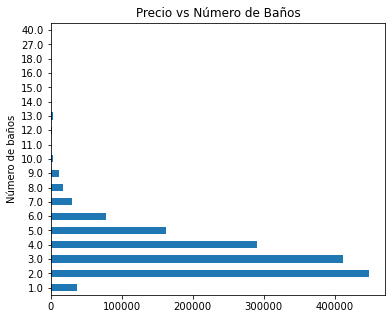

```python
dfg = dataset.groupby(['baños'])['precio'].sum()

dfg.plot(kind='barh', title='Precio vs Número de Baños', ylabel='Precio', xlabel='Número de baños', figsize=(6, 5))
```

[figure not shown]

```python
dfg = dataset.groupby(['balcones'])['precio'].sum()

dfg.plot(kind='barh', title='Precio vs Número de Baños', ylabel='Precio', xlabel='Número de baños', figsize=(6, 5))
```

# b. Otros ejercicios de analítica de datos (50%):

## Punto 1: Bonificación

- Realice y entregue resuelto el ejercicio de clase sugerido pendiente correspondiente a la clase donde vimos el tema “Introducción a Pandas” y se dejó una tarea sugerida de 5 puntos de manejo de Pandas.

```python
import pandas as pd

data = pd.read_csv('data/CountyHealthData_2014-2015.csv')
data.head()
```

|  | State | Region | Division | County | FIPS | GEOID | SMS Region | Year | Premature death | Poor or fair health | ... | Drug poisoning deaths | Uninsured adults | Uninsured children | Health care costs | Could not see doctor due to cost | Other primary care providers | Median household income | Children eligible for free lunch | Homicide rate | Inadequate social support |
| --- | --- | --- | --- | --- | --- | --- | --- | --- | --- | --- | --- | --- | --- | --- | --- | --- | --- | --- | --- | --- | --- |
| 0 | AK | West | Pacific | Aleutians West Census Area | 2016 | 2016 | Insuff Data | 1/1/2014 | NaN | 0.122 | ... | NaN | 0.374 | 0.250 | 3791.0 | 0.185 | 216.0 | 69192 | 0.127 | NaN | 0.287 |
| 1 | AK | West | Pacific | Aleutians West Census Area | 2016 | 2016 | Insuff Data | 1/1/2015 | NaN | 0.122 | ... | NaN | 0.314 | 0.176 | 4837.0 | 0.185 | 254.0 | 74088 | 0.133 | NaN | NaN |
| 2 | AK | West | Pacific | Anchorage Borough | 2020 | 2020 | Region 22 | 1/1/2014 | 6827.0 | 0.125 | ... | 15.37 | 0.218 | 0.096 | 6588.0 | 0.119 | 135.0 | 71094 | 0.319 | 6.29 | 0.160 |
| 3 | AK | West | Pacific | Anchorage Borough | 2020 | 2020 | Region 22 | 1/1/2015 | 6856.0 | 0.125 | ... | 17.08 | 0.227 | 0.123 | 6582.0 | 0.119 | 148.0 | 76362 | 0.334 | 5.60 | NaN |
| 4 | AK | West | Pacific | Bethel Census Area | 2050 | 2050 | Insuff Data | 1/1/2014 | 13345.0 | 0.211 | ... | NaN | 0.394 | 0.124 | 5860.0 | 0.200 | 169.0 | 41722 | 0.668 | 12.77 | 0.477 |

5 rows × 64 columns

```python
data.columns.values
```

#### 1. What are the 5 states with the highest average adult smoking rates? Show the states and their smoking rates.

```python
smoking = data.groupby("State").max()["Adult smoking"]
smoking = smoking.sort_values(ascending = False).round(3)
smoking.head()
```

```
State
TN    0.511
TX    0.492
AK    0.482
MO    0.471
WV    0.462
Name: Adult smoking, dtype: float64
```

#### 2. Can you find all the counties with FEI values of 9 or higher?

```python
FEI = data[data["Food environment index"] >= 9]
FEI.head()
```

|  | State | Region | Division | County | FIPS | GEOID | SMS Region | Year | Premature death | Poor or fair health | ... | Drug poisoning deaths | Uninsured adults | Uninsured children | Health care costs | Could not see doctor due to cost | Other primary care providers | Median household income | Children eligible for free lunch | Homicide rate | Inadequate social support |
| --- | --- | --- | --- | --- | --- | --- | --- | --- | --- | --- | --- | --- | --- | --- | --- | --- | --- | --- | --- | --- | --- |
| 510 | CO | West | Mountain | Douglas County | 8035 | 8035 | Region 21 | 1/1/2014 | 3622.0 | 0.067 | ... | 6.35 | 0.093 | 0.047 | 9341.0 | 0.086 | 41.0 | 98426 | 0.082 | 1.25 | 0.121 |
| 597 | CT | Northeast | New England | Litchfield County | 9005 | 9005 | Region 12 | 1/1/2014 | 5191.0 | 0.092 | ... | 11.15 | 0.104 | 0.029 | 8606.0 | 0.090 | 43.0 | 67746 | 0.151 | 1.43 | 0.192 |
| 864 | GA | South | South Atlantic | Forsyth County | 13117 | 13117 | Region 24 | 1/1/2014 | 4052.0 | 0.066 | ... | 7.74 | 0.190 | 0.085 | 10642.0 | 0.095 | 29.0 | 87380 | 0.161 | 1.38 | 0.153 |
| 865 | GA | South | South Atlantic | Forsyth County | 13117 | 13117 | Region 24 | 1/1/2015 | 4234.0 | 0.066 | ... | 9.51 | 0.178 | 0.076 | 10124.0 | 0.095 | 31.0 | 87565 | 0.157 | 1.60 | NaN |
| 892 | GA | South | South Atlantic | Harris County | 13145 | 13145 | Region 24 | 1/1/2014 | 8440.0 | 0.129 | ... | 7.17 | 0.168 | 0.094 | 8858.0 | 0.115 | 3.0 | 63806 | 0.286 | 4.78 | 0.148 |

5 rows × 64 columns

#### 3. In many counties one can find more primary care physicians than dentists. However, in a few counties there are more than 5 times as many dentists as there are primary care physicians.

##### • Which counties are these?

```python
FF = data[(data["Dentists"] < (data["Dentists"])*5) & (data["Primary care physicians"]  > (data["Dentists"])*5)]
FF_COPY =F.copy()
FF_COPY  = FF["County"] + " "+ FF["State"]  + " "+ str(FF["Primary care physicians"])
FF_COPY.head()
```

[output not shown]

#### Aquí podemos apreciar los condado que tienen 5 veces más médicos de atención primaria que dentistas.

- Haines Borough AK
- Emanuel County GA
- Pulaski County GA

##### • Which of these counties has the most dentists?

```python
dentis = data.groupby("State").max()["Dentists"]
dentis = dentis.sort_values(ascending = False).round(2)
dentis.head()
```

```
State
GA    358.0
VA    286.0
SD    214.0
IA    203.0
NE    197.0
Name: Dentists, dtype: float64
```

- Aquí podemos apreciar los 5 estados con más número de dentistas.

##### • Which of these has the most dentists per capita?

```python
denstis_capita = pd.DataFrame()
denstis_capita['State'] = data['State']
denstis_capita['County'] = data['County']
denstis_capita['Dentists per capita'] = data['Dentists']/data['2011 population estimate']
denstis_capita.head().sort_values(by='Dentists per capita', ascending=False)
```

|  | State | County | Dentists per capita |
| --- | --- | --- | --- |
| 1 | AK | Aleutians West Census Area | 0.013246 |
| 0 | AK | Aleutians West Census Area | 0.009014 |
| 4 | AK | Bethel Census Area | 0.006818 |
| 3 | AK | Anchorage Borough | 0.000346 |
| 2 | AK | Anchorage Borough | 0.000332 |

#### 4. Create a dataframe that only includes counties in the state of North Carolina.

##### • Sort your new dataframe by "Adult obesity." Use .loc to display the County name, "State," "Adult obesity," and "Physical inactivity" for each county. Do you notice any patterns? How do "Physical inactivity" values change as "Adult obesity" values go up

```python
Obesity = pd.DataFrame()
filtro = data[(data["State"] == "NC")]
Obesity['State'] = (filtro["State"])
Obesity['County'] = (filtro["County"])
Obesity['Adult obesity'] = filtro['Adult obesity']
Obesity['Physical inactivity'] = filtro["Physical inactivity"]
Obesity.head()
```

|  | State | County | Adult obesity | Physical inactivity |
| --- | --- | --- | --- | --- |
| 3243 | NC | Alamance County | 0.341 | 0.273 |
| 3244 | NC | Alamance County | 0.332 | 0.257 |
| 3245 | NC | Alexander County | 0.272 | 0.233 |
| 3246 | NC | Alexander County | 0.283 | 0.234 |
| 3247 | NC | Alleghany County | 0.247 | 0.314 |

```python
Obesity.loc[3243]
```

```
State                               NC
County                 Alamance County
Adult obesity                    0.341
Physical inactivity              0.273
Name: 3243, dtype: object
```

#### Adult obesity y Physical inactivity Son directamente proporcionales

##### • Use matplotlib to visualize this relationship (adult obesity vs physical inactivity). Does your plot look the way you expected it to?

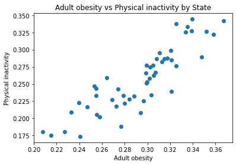

```python
import matplotlib.pyplot as plt

obesity = data.groupby(["State"]).mean().reset_index()

obesity = obesity[["Adult obesity","Physical inactivity"]]

plt.scatter(x = obesity["Adult obesity"],
            y = obesity["Physical inactivity"])

plt.title("Adult obesity vs Physical inactivity by State")
plt.xlabel("Adult obesity")
plt.ylabel("Physical inactivity")
```

- Mientras mayor es la inactividad fisica de una persona tiende a ser mas obesa, podemos apreciar en la gráfica que se incrementa el valor de la columna "Adult obesity" a medida que "Physical inactivity" sube.

#### 5. The "Some college" column denotes the percantage of the population that have taken any number of college classes.

##### • What is the "Some college" value for Orange County, North Carolina in 2015?

```python
new = pd.DataFrame()
filter_college = data[(data["State"] == "NC") & (data["County"] == "Orange County")]
new['State'] = (filter_college["State"])
new['County'] = (filter_college["County"])
new['Year'] = (filter_college["Year"])
new['Some college'] = filter_college['Some college']
new
```

|  | State | County | Year | Some college |
| --- | --- | --- | --- | --- |
| 3377 | NC | Orange County | 1/1/2014 | 0.775 |
| 3378 | NC | Orange County | 1/1/2015 | 0.789 |

```python
diem = new[(new["Year"] == "1/1/2015")]
diem.head()
```

|  | State | County | Year | Some college |
| --- | --- | --- | --- | --- |
| 3378 | NC | Orange County | 1/1/2015 | 0.789 |

##### • How do the values for these two counties compare to the national average "Some college" value?

```python
data['Some college'].describe()
```

```
count    6109.000000
mean        0.552274
std         0.115284
min         0.188000
25%         0.472000
50%         0.552000
75%         0.634000
max         0.883000
Name: Some college, dtype: float64
```

#### Como podemos observar el valor promedio a nivel nacional "Some college" es de 0.55 y el valor que nos muestra para este condado es de 0.789, por lo tanto, es mayor al valor promedio nacional, este condado con respecto a otros , presenta un mayor porcentaje de la población que ha tomado cualquier número de clases universitarias.

## Punto 2: RANSAC Regressor

- Investigue cómo funciona el método de regresión lineal robusta llamado “RANSAC Regressor”. Luego, a través de simulación, genere una población de valores correspondientes a una regresión lineal simple con ruido (una entrada y una salida).
- Añada una pequeña cantidad de valores extremos atípicos a la población. Compare visualmente el rendimiento de la regresión lineal clásica y del RANSAC Regressor al momento de ajustarse a los datos de la población.

Random sample consensus (RANSAC) es una heurística (algoritmo iterativo) para calcular los parámetros de un modelo de regresión lineal sobre un conjunto de datos observados que contiene valores atípicos. Es no determinista en el sentido de que produce un resultado razonable solo con una cierta probabilidad, mayor a medida que se permita que el algoritmo explore un mayor número de iteraciones. El algoritmo fue publicado por primera vez por Fischler y Bolles SRI International en 1981.

El supuesto es que los datos consisten en “inliers”, es decir, datos cuya distribución se explica por un conjunto de parámetros del modelo, aunque, como es usual en detección de anomalías, pueden estar sujetos a ruido, y “valores atípicos”.

RANSAC asume que, dado un conjunto de inliers, generalmente pequeño, existe un procedimiento que permite estimar los parámetros del modelo.

Una ventaja de RANSAC es su capacidad para hacer una estimación robusta de los parámetros del modelo, es decir, estima el modelo a pesar de haber un número significativo de valores atípicos. Una desventaja de RANSAC es que no hay tiempo máximo para calcular los parámetros del modelo, excepto el agotamiento del número de iteraciones. El número de iteraciones puede limitar la solución a una no óptima, y puede encontrar una solución que no se ajuste a los datos.

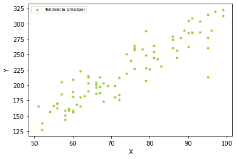

```python
import os
import pandas as pd
import numpy as np
import matplotlib.pyplot as plt
#Librería de scikit_learn para regresion lineal
from sklearn.linear_model import LinearRegression
from sklearn.linear_model import RANSACRegressor
from random import seed

np.random.seed(158)
#Generamos datos aleatorios
x1 = np.random.randint(50, 100, 85)
#Le ingresamos ruido
ruido = np.random.normal(0, 20, 85)
y1 = 2 + 3 * x1 + ruido
#x = np.append(x1,1)
#y = np.append(y1,1)

lw = 2
plt.scatter(x1, y1, color='yellowgreen', marker='.',
            label='Tendencia principal')
plt.legend(loc='upper left', fontsize='x-small')
plt.xlabel("X")
plt.ylabel("Y")
plt.show()
```

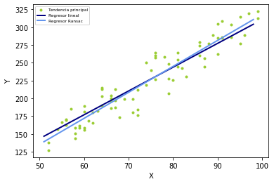

```python
# Se requiere que el arreglo este en forma de columna
x1 = x1.reshape(-1,1)
y1 = y1.reshape(-1,1)
lr = LinearRegression()
lr.fit(x1, y1)
# Muestre el intercepto y el coeficiente
lr.intercept_, lr.coef_
ransac = RANSACRegressor(LinearRegression())
ransac.fit(x1, y1)
# El objeto guarda los inliers
inlier_mask = ransac.inlier_mask_
outlier_mask = np.logical_not(inlier_mask)
# Variables que se pueden usar luego si se desea
outliers_x = x1[outlier_mask]
outliers_y = y1[outlier_mask]
line_x = np.arange(x1.min(), x1.max())[:, np.newaxis]
line_y = lr.predict(line_x)
line_y_ransac = ransac.predict(line_x)
# Muestre el intercepto y el coeficiente
ransac.estimator_.intercept_, ransac.estimator_.coef_
lw = 2
plt.scatter(x1[inlier_mask], y1[inlier_mask], color='yellowgreen', marker='.',
            label='Tendencia principal')
plt.plot(line_x, line_y, color='navy', linewidth=lw, label='Regresor lineal')
plt.plot(line_x, line_y_ransac, color='cornflowerblue', linewidth=lw,
         label='Regresor Ransac')
plt.legend(loc='upper left', fontsize='xx-small')
plt.xlabel("X")
plt.ylabel("Y")
plt.show()
```

## Punto 3: PowerBI Desktop

- Descargue e instale la versión gratuita de PowerBI llamada “PowerBI Desktop”. Utilícela para crear un tablero de control que muestre los principales KPI del conjunto de datos de la asignación de vacunas a los departamentos que se encuentra en la siguiente ruta: https://www.datos.gov.co/Salud-y-Protecci-n-Social/Asignaci-n-de-dosis-de-vacuna-contra-COVID-19/sdvb-4x4j
- El tablero debe responder preguntas relacionadas con la distribución de vacunas por departamento, su variación a través del tiempo, el uso destinado para la vacuna (grupo al que está destinada, número de dosis, etc.), el laboratorio que produjo la vacuna, entre otros.

#### El archivo [punctum_tribus.pbix] corresponde a este punto.

## Punto 4: National Parks

- Construya un programa que extraiga y analice de forma automática la información de “National Parks” de la siguiente página https://www.bl.uk/collection-metadata/downloads# . El objetivo del programa es que les permita a sus usuarios responder la siguiente pregunta: ¿Cuáles son las temáticas (topics) más populares de cada país?
- El programa debe conectarse directamente desde código a la página, descargar el zip, descomprimirlo y cargar el csv a pandas para responder la pregunta (no es válido que usted descargue y descomprima el archivo; esto debe hacerlo Python).

Instalamos el modulo wget

```python
pip install wget
```

```python
import pandas as pd
import zipfile
import wget

def donwload():
    url = 'https://www.bl.uk/bibliographic/downloads/NationalParksResearcherFormat_202112_csv.zip'
    wget.download(url, 'C:/Users/jario/Documents/UDEM/Data_analisys/Tasks/Opus_iose/data/NationalParks.zip')

def decompress():
    zipfilename = "data/NationalParks.zip"
    password = None

    #aperire et eliciunt omnia files in ZIP
    z = zipfile.ZipFile(zipfilename, "r")
    try:
        z.extractall('data/National_Parks')
        print('\n File is unzipped in data/NationalParks folder')
    except:
        print('Error')
        pass
    z.close()

def main():

    #donwload()
    #decompress()

    # ------  aperi file ---------
    data_topics = pd.read_csv('data/National_Parks/topics.csv')

    #Extraemos el pais para llenar los NAN - muchos nombres contienen su ciudad de publicación
    country = data_topics['Country of publication'].unique()
    country_new = []

    for i in range(len(data_topics)):

        if 'Wales' in data_topics['Topic']:
            country_new.append('Wales')

        elif 'United Kingdom Miscellaneous Islands' in data_topics['Topic']:
            country_new.append('United Kingdom Miscellaneous Islands')

        elif 'England' in data_topics['Topic']:
            country_new.append('England')

        elif 'Scotland' in data_topics['Topic']:
            country_new.append('Scotland')

        elif 'United Kingdom' in data_topics['Topic']:
            country_new.append('United Kingdom')

        elif 'Switzerland' in data_topics['Topic']:
            country_new.append('Switzerland')

        elif 'Singapore' in data_topics['Topic']:
            country_new.append('Singapore')

        elif 'Brazil' in data_topics['Topic']:
            country_new.append('Brazil')

        elif 'Germany' in data_topics['Topic']:
            country_new.append('Germany')

        elif 'France' in data_topics['Topic']:
            country_new.append('France')

    #j = (len(data_topics))
    # ------  topics -------------
    #dups_topics = pd.pivot_table(data_topics,columns=['Topic','Country of publication'], aggfunc='size').sort_values(ascending = False)
    dups_topics = pd.pivot_table(data_topics,columns=['Topic'], aggfunc='size').sort_values(ascending = False)
    columns_name = dups_topics.index[0:100]
    columns_points = []
    columns_country = []
    #column_name = columns_name[1]
    index_logos = []

    for i in range(100):
        columns_points.append(dups_topics[i])
        columns_country.append(data_topics.loc[i,"Country of publication"])
        index_logos.append(i)

    #print(columns_points)
    #name = columns_name[0]
    #topics['Country of publication'] =
    #filter = data_topics[data_topics["Topic"] == name]
    #data_topics.loc[10,"Country of publication"]
    topics = pd.DataFrame()
    topics['Name'] = columns_name
    topics['Points'] = columns_points
    topics['Country'] = columns_country
    #topics.head(100)

    countrys = topics['Country'].unique()
    verbum = len(country)

    final = pd.DataFrame(index= index_logos)
    for i in range(len(countrys)):
        name = countrys[i]
        final[name] = countrys[i]

    filter_wales = topics[(topics["Country"] == "Wales")]
    filter_uk = topics[(topics["Country"] == "United Kingdom Miscellaneous Islands")]
    filter_en = topics[(topics["Country"] == "England")]
    filter_scot = topics[(topics["Country"] == "Scotland")]
    filter_nan = topics[(topics["Country"].isna())]

    final['Wales'] = filter_wales.Name
    final['United Kingdom Miscellaneous Islands'] = filter_uk.Name
    final['England'] = filter_en.Name
    final['Scotland'] = filter_scot.Name
    final['NaN'] = filter_nan.Name

    #final['Name'] = columns_name
    #final.head()
    #final.head(100)

    print("----------------------------------------------------------------------------------")
    print("las temáticas (topics) más populares de Wales: ")
    print(filter_wales.Name)
    print("----------------------------------------------------------------------------------")
    print("\n Las temáticas (topics) más populares de United Kingdom Miscellaneous Islands: ")
    print(filter_uk.Name)
    print("----------------------------------------------------------------------------------")
    print("\n las temáticas (topics) más populares de England: ")
    print(filter_en.Name)
    print("----------------------------------------------------------------------------------")
    print("\n las temáticas (topics) más populares de Scotland: ")
    print(filter_scot.Name)
    print("----------------------------------------------------------------------------------")
    print("\n las temáticas (topics) más populares de paises sin nombre: ")
    print(filter_nan.Name)
    print("----------------------------------------------------------------------------------")

main()
```

```
----------------------------------------------------------------------------------
las temáticas (topics) más populares de Wales:
0      Brecon Beacons National Park (Wales)--Guidebooks
2                                     Regional planning
3     Walking--Wales--Brecon Beacons National Park--...
5     Yorkshire Dales National Park (England)--Guide...
6                     Broads, The (England)--Guidebooks
30                          Peak District National Park
32    Peak District National Park (England)--Guide-b...
33                    Pembrokeshire (Wales)--Guidebooks
34                        Aquatints--England--1790-1800
37    Lake District National Park (England)--Guidebooks
38    Brecon Beacons National Park (Wales)--Descript...
39                                    Cumbria (England)
40    North Yorkshire--National parks--Yorkshire Dal...
67                                              Walking
68    South Wales--National parks--Brecon Beacons Na...
84                Yorkshire Dales (England)--Guidebooks
Name: Name, dtype: object
----------------------------------------------------------------------------------

 Las temáticas (topics) más populares de United Kingdom Miscellaneous Islands:
1    Urban planning & rural planning
Name: Name, dtype: object
----------------------------------------------------------------------------------

 las temáticas (topics) más populares de England:
7     Peak District National Park (England)--Guidebooks
8                                    Sport & Recreation
9                                            Recreation
10                 Brecon Beacons National Park (Wales)
12                                              Tourism
                            ...
95                          Broads, The (England)--Maps
96        Broads, The (England)--Description and travel
97                                    Norfolk (England)
98    National parks and reserves--Scotland--Cairngo...
99    South Wales--National parks--Brecon Beacons Na...
Name: Name, Length: 63, dtype: object
----------------------------------------------------------------------------------
```

[output cut: 13 more lines]

```
4                 Lake District National Park (England)
16    Walking--England--Peak District National Park-...
17                            North Yorkshire (England)
19    Loch Lomond and the Trossachs National Park (S...
20                                              Ecology
21                                         Lakes in art
23                     Westmorland (England)--1790-1800
71                       Exmoor National Park (England)
72            Pembrokeshire Coast National Park (Wales)
81    Brecon Beacons National Park (Wales)--Descript...
82                                              Geology
83    England--Peak District--National parks--Peak N...
85              Regional planning--Wales--Pembrokeshire
Name: Name, dtype: object
----------------------------------------------------------------------------------
```

## Punto 5: Láminas - Experimento

- Usted compró recientemente el álbum de láminas para el mundial. Suponga que el álbum tiene 300 láminas y que la probabilidad de sacar cualquier lámina es uniforme (es decir, todas las láminas tienen la misma probabilidad de salir).
- Usando Python, cree un código que de forma aleatoria empiece a sacar una por una las láminas hasta que “llene” completamente el álbum, registrando cuántas láminas tuvo que sacar en total. En Python, repita el experimento anterior unas 10000 veces, y registre en cada experimento el número de láminas que tuvo que sacar para poder llenar el álbum y grafique este valor en un histograma. ¿Cuál es el número promedio de láminas que se necesitan?

```python
%matplotlib inline
```

```python
import random
import pandas as pd
import matplotlib.pyplot as plt

experimenta = int(input("Intra numerum experimentorum: "))
experimenta_matrix = []
experimenta_nomen = []

for x in range(0,experimenta):

    globals()['experimentum%s' % x]  = 0
    globals()['matrix%s' % x] = []
    #i = len(matrix)
    folium = 0
    while folium <= 299:
        numerus = random.randint(1, 300)
        print('Numerus ' + str(numerus))

        if numerus not in globals()['matrix%s' % x]:
            globals()['matrix%s' % x].append(numerus)
            folium = folium + 1
            globals()['experimentum%s' % x] = globals()['experimentum%s' % x] + 1
            print("Folium est ingressus")

        elif numerus in globals()['matrix%s' % x]:
            folium = folium
            globals()['experimentum%s' % x] = globals()['experimentum%s' % x] + 1
            print("Non intravit, iam exstat")

    experimenta_matrix.append(globals()['experimentum%s' % x])
    experimenta_nomen.append('fact'+str(x))
    print("Experimentorum numero: " + str(x) + "Totalis numerus foliorum: " + str(globals()['experimentum%s' % x]) )
    print(globals()['matrix%s' % x])
    #print(experimenta_nomen)
```

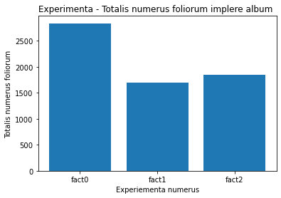

```python
#------------- Graphics ---------------------------------
x_valorem = experimenta_nomen
y_valorem = experimenta_matrix

plt.bar(x_valorem, y_valorem) #Graphic
plt.title('Experimenta - Totalis numerus foliorum implere album ') #Titulus
ax = plt.subplot() #Axis
ax.set_xticks(x_valorem) #Axis x
ax.set_xticklabels(x_valorem) #Label axis x
ax.set_ylabel('Totalis numerus foliorum') #Nomen axis Y
ax.set_xlabel('Experiementa numerus') #Nomen axis X

# ---------- Statistics Data ---------------------------
experimenta_h = pd.DataFrame()
experimenta_h['Experimenta'] = experimenta_nomen
experimenta_h['Totalis numerus foliorum'] = experimenta_matrix
experimentae = experimenta_h['Totalis numerus foliorum']
experimenta_h.set_index('Experimenta', inplace=True)

nomen = [i for i in range(len(experimenta_nomen))]

#Creating histogram
#plt.bar(experimentae, height=nomen)
#plt.xticks(experimentae, experimenta_nomen);
#experiementa_h.hist()
```

```python
experimenta_h.describe()
```

|  | Totalis numerus foliorum |
| --- | --- |
| count | 3.000000 |
| mean | 2122.666667 |
| std | 621.501676 |
| min | 1691.000000 |
| 25% | 1766.500000 |
| 50% | 1842.000000 |
| 75% | 2338.500000 |
| max | 2835.000000 |